# massive GST (version 20250326)

[S.M. Pagnotta](https://www.researchgate.net/profile/Stefano-Pagnotta-2) - Dept. of Science and Technology, Università degli Studi del Sannio (Benevento, Italy)

03/28/2025

This vignette shows how to use the massiveGST package.

# Installation

Get the stable release from CRAN

```r
install.packages("massiveGST")
```

On going bug correction and future improvements are in [github](https://github.com/stefanoMP/massiveGST).

```r
if (!requireNamespace("BiocManager", quietly = TRUE)) install.packages("BiocManager")
BiocManager::install("stefanoMP/massiveGST")
```

# Setup

```r
suppressPackageStartupMessages(library(massiveGST, quietly = TRUE))
```

## getting gene-profile from a file

In any cases, the names of the list have to match the gene names in any of their coding (gene-symbol, entrez, ensembl, etc.). To explain some details of the functions, we assume that positive values of the gene-profile are up-regulated in the treatment group, while the negative ones are up-regulated in the control group. In other words, the positive genes are associated with the treatment group, while the others are associated with the control samples.

Here, we consider the working gene-profile from [Frattini et al, 2018](https://www.nature.com/articles/nature25171), stored as external data in the package.

```r
fname <- system.file("extdata", package="massiveGST")
fname <- file.path(fname, "pre_ranked_list.txt")
geneProfile <- get_geneProfile(fname)
class(geneProfile)
```

```
## [1] "numeric"
```

```r
head(geneProfile)
```

```
##    WASF3     VAV3     PFKM     LGR6  SLC6A11 KIAA1147
## 4.819656 4.332110 4.244893 4.182461 4.088992 4.045543
```

```r
tail(geneProfile)
```

```
##      SLC47A2        STON1 DKFZp434K191      PLEKHO1        PDE6B       IFNGR2
##    -2.728522    -2.748892    -2.881312    -2.942627    -3.141299    -3.158738
```

## getting gene-sets from msigdbr

[msigdbr package](https://CRAN.R-project.org/package=msigdbr) is an R distribution of the most recent release of the [MSigDB](https://www.gsea-msigdb.org/gsea/msigdb/) collection of gene-sets. The function get_geneSets_from_msigdbr is a wrapper allowing the creation of a data structure for following gene-set enrichment analysis. Function parameters are those of the msigdbr function, except for ‘what’, allowing to choose the coding of the gene names.

This example extracts gene-sets where the gene-names are the gene symbols. Other possibilities have been specified in the ‘man’ fo the functions, and essentially they are the names of the columns of the data frame retrieved by the msigdbr function.

```r
fname <- system.file("extdata", package="massiveGST")
fname <- file.path(fname, "h.all.v2024.1.Hs.symbols.gmt")
geneSets <- get_geneSets_from_local_files(fname)
class(geneSets)
```

```
## [1] "list"
```

```r
head(names(geneSets))
```

```
## [1] "HALLMARK_ADIPOGENESIS"        "HALLMARK_ALLOGRAFT_REJECTION"
## [3] "HALLMARK_ANDROGEN_RESPONSE"   "HALLMARK_ANGIOGENESIS"
## [5] "HALLMARK_APICAL_JUNCTION"     "HALLMARK_APICAL_SURFACE"
```

Optionally, the gene-sets collection can be stored in gmt formatted file

```r
fname <- file.path(tempdir(), "hallmarks.gmt")
write_geneSets_to_gmt(geneSets, fileName = fname)
```

and retrieved with the code

```r
fname <- file.path(tempdir(), "hallmarks.gmt")
tmp <- get_geneSets_from_local_files(fname)

class(geneSets)
```

```
## [1] "list"
```

```r
head(names(geneSets))
```

```
## [1] "HALLMARK_ADIPOGENESIS"        "HALLMARK_ALLOGRAFT_REJECTION"
## [3] "HALLMARK_ANDROGEN_RESPONSE"   "HALLMARK_ANGIOGENESIS"
## [5] "HALLMARK_APICAL_JUNCTION"     "HALLMARK_APICAL_SURFACE"
```

# Running the analysis with alternative = “two.sided”

```r
system.time({ans <- massiveGST(geneProfile, geneSets, alternative = "two.sided")})
```

```
##    user  system elapsed
##   0.047   0.016   0.064
```

```r
class(ans)
```

```
## [1] "mGST"       "data.frame"
```

```r
ans[1:6,]
```

```
##                                    size actualSize       NES      odd logit2NES
## HALLMARK_OXIDATIVE_PHOSPHORYLATION  200        177 0.6907051 2.233160 1.1590869
## HALLMARK_ESTROGEN_RESPONSE_EARLY    200        182 0.5895587 1.436402 0.5224595
## HALLMARK_ADIPOGENESIS               200        176 0.5946149 1.466790 0.5526627
## HALLMARK_MITOTIC_SPINDLE            199        187 0.5508146 1.226252 0.2942556
## HALLMARK_BILE_ACID_METABOLISM       112        112 0.5856305 1.413305 0.4990726
## HALLMARK_FATTY_ACID_METABOLISM      158        148 0.5649870 1.298782 0.3771593
##                                    abs_logit2NES      p.value     BH.value
## HALLMARK_OXIDATIVE_PHOSPHORYLATION     1.1590869 2.230464e-18 2.788080e-17
## HALLMARK_ESTROGEN_RESPONSE_EARLY       0.5224595 3.129669e-05 1.564834e-04
## HALLMARK_ADIPOGENESIS                  0.5526627 1.514858e-05 8.415875e-05
## HALLMARK_MITOTIC_SPINDLE               0.2942556 1.664775e-02 4.380987e-02
## HALLMARK_BILE_ACID_METABOLISM          0.4990726 1.752278e-03 6.226110e-03
## HALLMARK_FATTY_ACID_METABOLISM         0.3771593 6.386537e-03 1.995793e-02
##                                         B.value relevance
## HALLMARK_OXIDATIVE_PHOSPHORYLATION 1.115232e-16      59.5
## HALLMARK_ESTROGEN_RESPONSE_EARLY   1.564834e-03      59.0
## HALLMARK_ADIPOGENESIS              7.574288e-04      56.0
## HALLMARK_MITOTIC_SPINDLE           8.323875e-01      52.5
## HALLMARK_BILE_ACID_METABOLISM      8.761391e-02      48.0
## HALLMARK_FATTY_ACID_METABOLISM     3.193268e-01      48.0
##                                                                                                                        link
## HALLMARK_OXIDATIVE_PHOSPHORYLATION https://www.gsea-msigdb.org/gsea/msigdb/human/geneset/HALLMARK_OXIDATIVE_PHOSPHORYLATION
## HALLMARK_ESTROGEN_RESPONSE_EARLY     https://www.gsea-msigdb.org/gsea/msigdb/human/geneset/HALLMARK_ESTROGEN_RESPONSE_EARLY
## HALLMARK_ADIPOGENESIS                           https://www.gsea-msigdb.org/gsea/msigdb/human/geneset/HALLMARK_ADIPOGENESIS
## HALLMARK_MITOTIC_SPINDLE                     https://www.gsea-msigdb.org/gsea/msigdb/human/geneset/HALLMARK_MITOTIC_SPINDLE
## HALLMARK_BILE_ACID_METABOLISM           https://www.gsea-msigdb.org/gsea/msigdb/human/geneset/HALLMARK_BILE_ACID_METABOLISM
## HALLMARK_FATTY_ACID_METABOLISM         https://www.gsea-msigdb.org/gsea/msigdb/human/geneset/HALLMARK_FATTY_ACID_METABOLISM
```

The analysis result is essentially a data frame; the first class ‘mGST’ allows hooking other methods to handle the output.

The results can be saved in tab-separated value (tsv) format or an XLS format file.

```r
fname <- file.path(tempdir(), "massiveGST_results.tsv")
save_as_tsv(ans, file_name = fname)

fname <- file.path(tempdir(), "massiveGST_results.xls")
save_as_xls(ans, file_name = fname)
```

## The summary method.

The summary function allows customizing the result of the analysis.

```r
summary(ans)[1:10,]
```

```
##                                    size actualSize    NES logit2NES p.value
## HALLMARK_OXIDATIVE_PHOSPHORYLATION  200        177 0.6907    1.1591 2.2e-18
## HALLMARK_ESTROGEN_RESPONSE_EARLY    200        182 0.5896    0.5225 3.1e-05
## HALLMARK_ADIPOGENESIS               200        176 0.5946    0.5527 1.5e-05
## HALLMARK_MITOTIC_SPINDLE            199        187 0.5508    0.2943 1.7e-02
## HALLMARK_BILE_ACID_METABOLISM       112        112 0.5856    0.4991 1.8e-03
## HALLMARK_FATTY_ACID_METABOLISM      158        148 0.5650    0.3772 6.4e-03
## HALLMARK_G2M_CHECKPOINT             200        178 0.5475    0.2748 2.9e-02
## HALLMARK_MTORC1_SIGNALING           200        187 0.5376    0.2172 7.7e-02
## HALLMARK_UV_RESPONSE_DN             144        132 0.5528    0.3059 3.6e-02
## HALLMARK_HEME_METABOLISM            200        180 0.5325    0.1877 1.3e-01
##                                    BH.value B.value relevance
## HALLMARK_OXIDATIVE_PHOSPHORYLATION  2.8e-17 1.1e-16      59.5
## HALLMARK_ESTROGEN_RESPONSE_EARLY    1.6e-04 1.6e-03      59.0
## HALLMARK_ADIPOGENESIS               8.4e-05 7.6e-04      56.0
## HALLMARK_MITOTIC_SPINDLE            4.4e-02 8.3e-01      52.5
## HALLMARK_BILE_ACID_METABOLISM       6.2e-03 8.8e-02      48.0
## HALLMARK_FATTY_ACID_METABOLISM      2.0e-02 3.2e-01      48.0
## HALLMARK_G2M_CHECKPOINT             6.9e-02 1.0e+00      47.0
## HALLMARK_MTORC1_SIGNALING           1.6e-01 1.0e+00      46.5
## HALLMARK_UV_RESPONSE_DN             8.2e-02 1.0e+00      42.0
## HALLMARK_HEME_METABOLISM            2.5e-01 1.0e+00      41.0
```

With it:

- The ordering of the table can be chosen.

```r
summary(ans, order_by = "NES")[1:10,]
```

```
##                                    size actualSize    NES logit2NES p.value
## HALLMARK_OXIDATIVE_PHOSPHORYLATION  200        177 0.6907    1.1591 2.2e-18
## HALLMARK_ADIPOGENESIS               200        176 0.5946    0.5527 1.5e-05
## HALLMARK_ESTROGEN_RESPONSE_EARLY    200        182 0.5896    0.5225 3.1e-05
## HALLMARK_BILE_ACID_METABOLISM       112        112 0.5856    0.4991 1.8e-03
## HALLMARK_FATTY_ACID_METABOLISM      158        148 0.5650    0.3772 6.4e-03
## HALLMARK_NOTCH_SIGNALING             32         30 0.5572    0.3316 2.8e-01
## HALLMARK_UV_RESPONSE_DN             144        132 0.5528    0.3059 3.6e-02
## HALLMARK_MITOTIC_SPINDLE            199        187 0.5508    0.2943 1.7e-02
## HALLMARK_G2M_CHECKPOINT             200        178 0.5475    0.2748 2.9e-02
## HALLMARK_PROTEIN_SECRETION           96         93 0.5459    0.2656 1.3e-01
##                                    BH.value B.value
## HALLMARK_OXIDATIVE_PHOSPHORYLATION  2.8e-17 1.1e-16
## HALLMARK_ADIPOGENESIS               8.4e-05 7.6e-04
## HALLMARK_ESTROGEN_RESPONSE_EARLY    1.6e-04 1.6e-03
## HALLMARK_BILE_ACID_METABOLISM       6.2e-03 8.8e-02
## HALLMARK_FATTY_ACID_METABOLISM      2.0e-02 3.2e-01
## HALLMARK_NOTCH_SIGNALING            4.2e-01 1.0e+00
## HALLMARK_UV_RESPONSE_DN             8.2e-02 1.0e+00
## HALLMARK_MITOTIC_SPINDLE            4.4e-02 8.3e-01
## HALLMARK_G2M_CHECKPOINT             6.9e-02 1.0e+00
## HALLMARK_PROTEIN_SECRETION          2.5e-01 1.0e+00
```

```r
summary(ans, order_by = "p.value")[1:10,]
```

```
##                                    size actualSize    NES logit2NES p.value
## HALLMARK_INTERFERON_GAMMA_RESPONSE  200        186 0.2458   -1.6175 6.8e-33
## HALLMARK_INTERFERON_ALPHA_RESPONSE   97         87 0.1688   -2.3000 1.3e-26
## HALLMARK_ALLOGRAFT_REJECTION        200        189 0.2816   -1.3512 4.4e-25
## HALLMARK_OXIDATIVE_PHOSPHORYLATION  200        177 0.6907    1.1591 2.2e-18
## HALLMARK_INFLAMMATORY_RESPONSE      200        192 0.3517   -0.8825 1.4e-12
## HALLMARK_TNFA_SIGNALING_VIA_NFKB    200        185 0.3549   -0.8624 1.0e-11
## HALLMARK_IL6_JAK_STAT3_SIGNALING     87         83 0.3064   -1.1789 1.1e-09
## HALLMARK_COMPLEMENT                 200        190 0.3869   -0.6643 7.8e-08
## HALLMARK_ADIPOGENESIS               200        176 0.5946    0.5527 1.5e-05
## HALLMARK_ESTROGEN_RESPONSE_EARLY    200        182 0.5896    0.5225 3.1e-05
##                                    BH.value B.value
## HALLMARK_INTERFERON_GAMMA_RESPONSE  3.4e-31 3.4e-31
## HALLMARK_INTERFERON_ALPHA_RESPONSE  3.3e-25 6.6e-25
## HALLMARK_ALLOGRAFT_REJECTION        7.3e-24 2.2e-23
## HALLMARK_OXIDATIVE_PHOSPHORYLATION  2.8e-17 1.1e-16
## HALLMARK_INFLAMMATORY_RESPONSE      1.4e-11 7.2e-11
## HALLMARK_TNFA_SIGNALING_VIA_NFKB    8.5e-11 5.1e-10
## HALLMARK_IL6_JAK_STAT3_SIGNALING    7.7e-09 5.4e-08
## HALLMARK_COMPLEMENT                 4.9e-07 3.9e-06
## HALLMARK_ADIPOGENESIS               8.4e-05 7.6e-04
## HALLMARK_ESTROGEN_RESPONSE_EARLY    1.6e-04 1.6e-03
```

```r
summary(ans, order_by = "bonferroni")[1:10,]
```

```
##                                    size actualSize    NES logit2NES p.value
## HALLMARK_INTERFERON_GAMMA_RESPONSE  200        186 0.2458   -1.6175 6.8e-33
## HALLMARK_INTERFERON_ALPHA_RESPONSE   97         87 0.1688   -2.3000 1.3e-26
## HALLMARK_ALLOGRAFT_REJECTION        200        189 0.2816   -1.3512 4.4e-25
## HALLMARK_OXIDATIVE_PHOSPHORYLATION  200        177 0.6907    1.1591 2.2e-18
## HALLMARK_INFLAMMATORY_RESPONSE      200        192 0.3517   -0.8825 1.4e-12
## HALLMARK_TNFA_SIGNALING_VIA_NFKB    200        185 0.3549   -0.8624 1.0e-11
## HALLMARK_IL6_JAK_STAT3_SIGNALING     87         83 0.3064   -1.1789 1.1e-09
## HALLMARK_COMPLEMENT                 200        190 0.3869   -0.6643 7.8e-08
## HALLMARK_ADIPOGENESIS               200        176 0.5946    0.5527 1.5e-05
## HALLMARK_ESTROGEN_RESPONSE_EARLY    200        182 0.5896    0.5225 3.1e-05
##                                    BH.value B.value
## HALLMARK_INTERFERON_GAMMA_RESPONSE  3.4e-31 3.4e-31
## HALLMARK_INTERFERON_ALPHA_RESPONSE  3.3e-25 6.6e-25
## HALLMARK_ALLOGRAFT_REJECTION        7.3e-24 2.2e-23
## HALLMARK_OXIDATIVE_PHOSPHORYLATION  2.8e-17 1.1e-16
## HALLMARK_INFLAMMATORY_RESPONSE      1.4e-11 7.2e-11
## HALLMARK_TNFA_SIGNALING_VIA_NFKB    8.5e-11 5.1e-10
## HALLMARK_IL6_JAK_STAT3_SIGNALING    7.7e-09 5.4e-08
## HALLMARK_COMPLEMENT                 4.9e-07 3.9e-06
## HALLMARK_ADIPOGENESIS               8.4e-05 7.6e-04
## HALLMARK_ESTROGEN_RESPONSE_EARLY    1.6e-04 1.6e-03
```

- Some columns can be removed.

```r
(tmp <- summary(ans, order_by = "p.value", cols_to_remove = c("BH.value", "B.value"))[1:10,])
```

```
##                                    size actualSize    NES logit2NES p.value
## HALLMARK_INTERFERON_GAMMA_RESPONSE  200        186 0.2458   -1.6175 6.8e-33
## HALLMARK_INTERFERON_ALPHA_RESPONSE   97         87 0.1688   -2.3000 1.3e-26
## HALLMARK_ALLOGRAFT_REJECTION        200        189 0.2816   -1.3512 4.4e-25
## HALLMARK_OXIDATIVE_PHOSPHORYLATION  200        177 0.6907    1.1591 2.2e-18
## HALLMARK_INFLAMMATORY_RESPONSE      200        192 0.3517   -0.8825 1.4e-12
## HALLMARK_TNFA_SIGNALING_VIA_NFKB    200        185 0.3549   -0.8624 1.0e-11
## HALLMARK_IL6_JAK_STAT3_SIGNALING     87         83 0.3064   -1.1789 1.1e-09
## HALLMARK_COMPLEMENT                 200        190 0.3869   -0.6643 7.8e-08
## HALLMARK_ADIPOGENESIS               200        176 0.5946    0.5527 1.5e-05
## HALLMARK_ESTROGEN_RESPONSE_EARLY    200        182 0.5896    0.5225 3.1e-05
##                                                                                                                        link
## HALLMARK_INTERFERON_GAMMA_RESPONSE https://www.gsea-msigdb.org/gsea/msigdb/human/geneset/HALLMARK_INTERFERON_GAMMA_RESPONSE
## HALLMARK_INTERFERON_ALPHA_RESPONSE https://www.gsea-msigdb.org/gsea/msigdb/human/geneset/HALLMARK_INTERFERON_ALPHA_RESPONSE
## HALLMARK_ALLOGRAFT_REJECTION             https://www.gsea-msigdb.org/gsea/msigdb/human/geneset/HALLMARK_ALLOGRAFT_REJECTION
## HALLMARK_OXIDATIVE_PHOSPHORYLATION https://www.gsea-msigdb.org/gsea/msigdb/human/geneset/HALLMARK_OXIDATIVE_PHOSPHORYLATION
## HALLMARK_INFLAMMATORY_RESPONSE         https://www.gsea-msigdb.org/gsea/msigdb/human/geneset/HALLMARK_INFLAMMATORY_RESPONSE
## HALLMARK_TNFA_SIGNALING_VIA_NFKB     https://www.gsea-msigdb.org/gsea/msigdb/human/geneset/HALLMARK_TNFA_SIGNALING_VIA_NFKB
## HALLMARK_IL6_JAK_STAT3_SIGNALING     https://www.gsea-msigdb.org/gsea/msigdb/human/geneset/HALLMARK_IL6_JAK_STAT3_SIGNALING
## HALLMARK_COMPLEMENT                               https://www.gsea-msigdb.org/gsea/msigdb/human/geneset/HALLMARK_COMPLEMENT
## HALLMARK_ADIPOGENESIS                           https://www.gsea-msigdb.org/gsea/msigdb/human/geneset/HALLMARK_ADIPOGENESIS
## HALLMARK_ESTROGEN_RESPONSE_EARLY     https://www.gsea-msigdb.org/gsea/msigdb/human/geneset/HALLMARK_ESTROGEN_RESPONSE_EARLY
```

- The [formattable package](https://CRAN.R-project.org/package=formattable) can be invoked to get a more readable table.

```r
summary(ans, as.formattable = TRUE)
```

|  | size | actualSize | NES | logit2NES | p.value | BH.value | B.value | relevance |
| --- | --- | --- | --- | --- | --- | --- | --- | --- |
| HALLMARK_OXIDATIVE_PHOSPHORYLATION | 200 | 177 | 0.6907 | 1.1591 | 2.2e-18 | 2.8e-17 | 1.1e-16 | 59.5 |
| HALLMARK_ESTROGEN_RESPONSE_EARLY | 200 | 182 | 0.5896 | 0.5225 | 3.1e-05 | 1.6e-04 | 1.6e-03 | 59.0 |
| HALLMARK_ADIPOGENESIS | 200 | 176 | 0.5946 | 0.5527 | 1.5e-05 | 8.4e-05 | 7.6e-04 | 56.0 |
| HALLMARK_MITOTIC_SPINDLE | 199 | 187 | 0.5508 | 0.2943 | 1.7e-02 | 4.4e-02 | 8.3e-01 | 52.5 |
| HALLMARK_BILE_ACID_METABOLISM | 112 | 112 | 0.5856 | 0.4991 | 1.8e-03 | 6.2e-03 | 8.8e-02 | 48.0 |
| HALLMARK_FATTY_ACID_METABOLISM | 158 | 148 | 0.5650 | 0.3772 | 6.4e-03 | 2.0e-02 | 3.2e-01 | 48.0 |
| HALLMARK_G2M_CHECKPOINT | 200 | 178 | 0.5475 | 0.2748 | 2.9e-02 | 6.9e-02 | 1.0e+00 | 47.0 |
| HALLMARK_MTORC1_SIGNALING | 200 | 187 | 0.5376 | 0.2172 | 7.7e-02 | 1.6e-01 | 1.0e+00 | 46.5 |
| HALLMARK_UV_RESPONSE_DN | 144 | 132 | 0.5528 | 0.3059 | 3.6e-02 | 8.2e-02 | 1.0e+00 | 42.0 |
| HALLMARK_HEME_METABOLISM | 200 | 180 | 0.5325 | 0.1877 | 1.3e-01 | 2.5e-01 | 1.0e+00 | 41.0 |
| HALLMARK_PROTEIN_SECRETION | 96 | 93 | 0.5459 | 0.2656 | 1.3e-01 | 2.5e-01 | 1.0e+00 | 32.0 |
| HALLMARK_MYC_TARGETS_V1 | 200 | 177 | 0.5202 | 0.1165 | 3.5e-01 | 4.8e-01 | 1.0e+00 | 31.5 |
| HALLMARK_NOTCH_SIGNALING | 32 | 30 | 0.5572 | 0.3316 | 2.8e-01 | 4.2e-01 | 1.0e+00 | 29.0 |
| HALLMARK_ESTROGEN_RESPONSE_LATE | 200 | 191 | 0.5057 | 0.0326 | 7.9e-01 | 8.2e-01 | 1.0e+00 | 28.0 |
| HALLMARK_UNFOLDED_PROTEIN_RESPONSE | 113 | 101 | 0.5285 | 0.1647 | 3.2e-01 | 4.7e-01 | 1.0e+00 | 27.0 |
| HALLMARK_E2F_TARGETS | 200 | 171 | 0.5113 | 0.0651 | 6.1e-01 | 6.8e-01 | 1.0e+00 | 22.0 |
| HALLMARK_PEROXISOME | 104 | 100 | 0.5181 | 0.1047 | 5.3e-01 | 6.0e-01 | 1.0e+00 | 20.0 |
| HALLMARK_WNT_BETA_CATENIN_SIGNALING | 42 | 41 | 0.5308 | 0.1782 | 4.9e-01 | 5.9e-01 | 1.0e+00 | 20.0 |
| HALLMARK_ANGIOGENESIS | 36 | 36 | 0.5321 | 0.1856 | 5.0e-01 | 5.9e-01 | 1.0e+00 | 19.0 |
| HALLMARK_ANDROGEN_RESPONSE | 101 | 91 | 0.5133 | 0.0765 | 6.6e-01 | 7.2e-01 | 1.0e+00 | 14.0 |
| HALLMARK_PI3K_AKT_MTOR_SIGNALING | 105 | 99 | 0.5016 | 0.0090 | 9.6e-01 | 9.8e-01 | 1.0e+00 | 11.0 |
| HALLMARK_CHOLESTEROL_HOMEOSTASIS | 74 | 70 | 0.5008 | 0.0049 | 9.8e-01 | 9.8e-01 | 1.0e+00 | 6.0 |
| HALLMARK_HEDGEHOG_SIGNALING | 36 | 35 | 0.4661 | -0.1958 | 4.9e-01 | 5.9e-01 | 1.0e+00 | -11.0 |
| HALLMARK_MYC_TARGETS_V2 | 58 | 49 | 0.4716 | -0.1639 | 4.9e-01 | 5.9e-01 | 1.0e+00 | -12.0 |
| HALLMARK_APICAL_SURFACE | 44 | 41 | 0.4641 | -0.2073 | 4.3e-01 | 5.5e-01 | 1.0e+00 | -16.0 |
| HALLMARK_PANCREAS_BETA_CELLS | 40 | 40 | 0.4560 | -0.2544 | 3.4e-01 | 4.8e-01 | 1.0e+00 | -21.0 |
| HALLMARK_KRAS_SIGNALING_DN | 200 | 181 | 0.4795 | -0.1181 | 3.4e-01 | 4.8e-01 | 1.0e+00 | -24.5 |
| HALLMARK_XENOBIOTIC_METABOLISM | 200 | 189 | 0.4930 | -0.0405 | 7.4e-01 | 7.9e-01 | 1.0e+00 | -25.5 |
| HALLMARK_REACTIVE_OXYGEN_SPECIES_PATHWAY | 49 | 44 | 0.4501 | -0.2888 | 2.5e-01 | 4.1e-01 | 1.0e+00 | -28.0 |
| HALLMARK_APICAL_JUNCTION | 200 | 185 | 0.4760 | -0.1387 | 2.6e-01 | 4.1e-01 | 1.0e+00 | -30.0 |
| HALLMARK_TGF_BETA_SIGNALING | 54 | 52 | 0.4511 | -0.2829 | 2.2e-01 | 3.7e-01 | 1.0e+00 | -30.0 |
| HALLMARK_DNA_REPAIR | 150 | 134 | 0.4646 | -0.2048 | 1.6e-01 | 2.8e-01 | 1.0e+00 | -31.0 |
| HALLMARK_SPERMATOGENESIS | 135 | 122 | 0.4610 | -0.2258 | 1.4e-01 | 2.5e-01 | 1.0e+00 | -32.0 |
| HALLMARK_P53_PATHWAY | 200 | 181 | 0.4716 | -0.1640 | 1.9e-01 | 3.2e-01 | 1.0e+00 | -32.5 |
| HALLMARK_MYOGENESIS | 200 | 194 | 0.4830 | -0.0984 | 4.1e-01 | 5.4e-01 | 1.0e+00 | -35.0 |
| HALLMARK_UV_RESPONSE_UP | 158 | 148 | 0.4567 | -0.2504 | 6.9e-02 | 1.5e-01 | 1.0e+00 | -37.0 |
| HALLMARK_KRAS_SIGNALING_UP | 200 | 185 | 0.4523 | -0.2764 | 2.5e-02 | 6.3e-02 | 1.0e+00 | -46.0 |
| HALLMARK_COAGULATION | 138 | 132 | 0.4100 | -0.5250 | 3.6e-04 | 1.4e-03 | 1.8e-02 | -50.0 |
| HALLMARK_APOPTOSIS | 161 | 157 | 0.4170 | -0.4835 | 3.3e-04 | 1.4e-03 | 1.7e-02 | -52.0 |
| HALLMARK_GLYCOLYSIS | 200 | 187 | 0.4489 | -0.2961 | 1.6e-02 | 4.4e-02 | 8.0e-01 | -54.0 |
| HALLMARK_IL2_STAT5_SIGNALING | 199 | 179 | 0.4159 | -0.4902 | 1.0e-04 | 4.8e-04 | 5.2e-03 | -55.0 |
| HALLMARK_IL6_JAK_STAT3_SIGNALING | 87 | 83 | 0.3064 | -1.1789 | 1.1e-09 | 7.7e-09 | 5.4e-08 | -55.0 |
| HALLMARK_HYPOXIA | 200 | 186 | 0.4338 | -0.3842 | 1.9e-03 | 6.2e-03 | 9.3e-02 | -56.5 |
| HALLMARK_EPITHELIAL_MESENCHYMAL_TRANSITION | 200 | 191 | 0.4449 | -0.3191 | 8.7e-03 | 2.6e-02 | 4.4e-01 | -60.0 |
| HALLMARK_INTERFERON_ALPHA_RESPONSE | 97 | 87 | 0.1688 | -2.3000 | 1.3e-26 | 3.3e-25 | 6.6e-25 | -63.0 |
| HALLMARK_TNFA_SIGNALING_VIA_NFKB | 200 | 185 | 0.3549 | -0.8624 | 1.0e-11 | 8.5e-11 | 5.1e-10 | -65.0 |
| HALLMARK_COMPLEMENT | 200 | 190 | 0.3869 | -0.6643 | 7.8e-08 | 4.9e-07 | 3.9e-06 | -69.0 |
| HALLMARK_INTERFERON_GAMMA_RESPONSE | 200 | 186 | 0.2458 | -1.6175 | 6.8e-33 | 3.4e-31 | 3.4e-31 | -74.5 |
| HALLMARK_INFLAMMATORY_RESPONSE | 200 | 192 | 0.3517 | -0.8825 | 1.4e-12 | 1.4e-11 | 7.2e-11 | -76.0 |
| HALLMARK_ALLOGRAFT_REJECTION | 200 | 189 | 0.2816 | -1.3512 | 4.4e-25 | 7.3e-24 | 2.2e-23 | -76.5 |

```r
summary(ans, order_by = "p.value", cols_to_remove = c("BH.value", "B.value"), as.formattable = TRUE)
```

|  | size | actualSize | NES | logit2NES | p.value | link |
| --- | --- | --- | --- | --- | --- | --- |
| HALLMARK_INTERFERON_GAMMA_RESPONSE | 200 | 186 | 0.2458 | -1.6175 | 6.8e-33 | https://www.gsea-msigdb.org/gsea/msigdb/human/geneset/HALLMARK_INTERFERON_GAMMA_RESPONSE |
| HALLMARK_INTERFERON_ALPHA_RESPONSE | 97 | 87 | 0.1688 | -2.3000 | 1.3e-26 | https://www.gsea-msigdb.org/gsea/msigdb/human/geneset/HALLMARK_INTERFERON_ALPHA_RESPONSE |
| HALLMARK_ALLOGRAFT_REJECTION | 200 | 189 | 0.2816 | -1.3512 | 4.4e-25 | https://www.gsea-msigdb.org/gsea/msigdb/human/geneset/HALLMARK_ALLOGRAFT_REJECTION |
| HALLMARK_OXIDATIVE_PHOSPHORYLATION | 200 | 177 | 0.6907 | 1.1591 | 2.2e-18 | https://www.gsea-msigdb.org/gsea/msigdb/human/geneset/HALLMARK_OXIDATIVE_PHOSPHORYLATION |
| HALLMARK_INFLAMMATORY_RESPONSE | 200 | 192 | 0.3517 | -0.8825 | 1.4e-12 | https://www.gsea-msigdb.org/gsea/msigdb/human/geneset/HALLMARK_INFLAMMATORY_RESPONSE |
| HALLMARK_TNFA_SIGNALING_VIA_NFKB | 200 | 185 | 0.3549 | -0.8624 | 1.0e-11 | https://www.gsea-msigdb.org/gsea/msigdb/human/geneset/HALLMARK_TNFA_SIGNALING_VIA_NFKB |
| HALLMARK_IL6_JAK_STAT3_SIGNALING | 87 | 83 | 0.3064 | -1.1789 | 1.1e-09 | https://www.gsea-msigdb.org/gsea/msigdb/human/geneset/HALLMARK_IL6_JAK_STAT3_SIGNALING |
| HALLMARK_COMPLEMENT | 200 | 190 | 0.3869 | -0.6643 | 7.8e-08 | https://www.gsea-msigdb.org/gsea/msigdb/human/geneset/HALLMARK_COMPLEMENT |
| HALLMARK_ADIPOGENESIS | 200 | 176 | 0.5946 | 0.5527 | 1.5e-05 | https://www.gsea-msigdb.org/gsea/msigdb/human/geneset/HALLMARK_ADIPOGENESIS |
| HALLMARK_ESTROGEN_RESPONSE_EARLY | 200 | 182 | 0.5896 | 0.5225 | 3.1e-05 | https://www.gsea-msigdb.org/gsea/msigdb/human/geneset/HALLMARK_ESTROGEN_RESPONSE_EARLY |
| HALLMARK_IL2_STAT5_SIGNALING | 199 | 179 | 0.4159 | -0.4902 | 1.0e-04 | https://www.gsea-msigdb.org/gsea/msigdb/human/geneset/HALLMARK_IL2_STAT5_SIGNALING |
| HALLMARK_APOPTOSIS | 161 | 157 | 0.4170 | -0.4835 | 3.3e-04 | https://www.gsea-msigdb.org/gsea/msigdb/human/geneset/HALLMARK_APOPTOSIS |
| HALLMARK_COAGULATION | 138 | 132 | 0.4100 | -0.5250 | 3.6e-04 | https://www.gsea-msigdb.org/gsea/msigdb/human/geneset/HALLMARK_COAGULATION |
| HALLMARK_BILE_ACID_METABOLISM | 112 | 112 | 0.5856 | 0.4991 | 1.8e-03 | https://www.gsea-msigdb.org/gsea/msigdb/human/geneset/HALLMARK_BILE_ACID_METABOLISM |
| HALLMARK_HYPOXIA | 200 | 186 | 0.4338 | -0.3842 | 1.9e-03 | https://www.gsea-msigdb.org/gsea/msigdb/human/geneset/HALLMARK_HYPOXIA |
| HALLMARK_FATTY_ACID_METABOLISM | 158 | 148 | 0.5650 | 0.3772 | 6.4e-03 | https://www.gsea-msigdb.org/gsea/msigdb/human/geneset/HALLMARK_FATTY_ACID_METABOLISM |
| HALLMARK_EPITHELIAL_MESENCHYMAL_TRANSITION | 200 | 191 | 0.4449 | -0.3191 | 8.7e-03 | https://www.gsea-msigdb.org/gsea/msigdb/human/geneset/HALLMARK_EPITHELIAL_MESENCHYMAL_TRANSITION |
| HALLMARK_GLYCOLYSIS | 200 | 187 | 0.4489 | -0.2961 | 1.6e-02 | https://www.gsea-msigdb.org/gsea/msigdb/human/geneset/HALLMARK_GLYCOLYSIS |
| HALLMARK_MITOTIC_SPINDLE | 199 | 187 | 0.5508 | 0.2943 | 1.7e-02 | https://www.gsea-msigdb.org/gsea/msigdb/human/geneset/HALLMARK_MITOTIC_SPINDLE |
| HALLMARK_KRAS_SIGNALING_UP | 200 | 185 | 0.4523 | -0.2764 | 2.5e-02 | https://www.gsea-msigdb.org/gsea/msigdb/human/geneset/HALLMARK_KRAS_SIGNALING_UP |
| HALLMARK_G2M_CHECKPOINT | 200 | 178 | 0.5475 | 0.2748 | 2.9e-02 | https://www.gsea-msigdb.org/gsea/msigdb/human/geneset/HALLMARK_G2M_CHECKPOINT |
| HALLMARK_UV_RESPONSE_DN | 144 | 132 | 0.5528 | 0.3059 | 3.6e-02 | https://www.gsea-msigdb.org/gsea/msigdb/human/geneset/HALLMARK_UV_RESPONSE_DN |
| HALLMARK_UV_RESPONSE_UP | 158 | 148 | 0.4567 | -0.2504 | 6.9e-02 | https://www.gsea-msigdb.org/gsea/msigdb/human/geneset/HALLMARK_UV_RESPONSE_UP |
| HALLMARK_MTORC1_SIGNALING | 200 | 187 | 0.5376 | 0.2172 | 7.7e-02 | https://www.gsea-msigdb.org/gsea/msigdb/human/geneset/HALLMARK_MTORC1_SIGNALING |
| HALLMARK_PROTEIN_SECRETION | 96 | 93 | 0.5459 | 0.2656 | 1.3e-01 | https://www.gsea-msigdb.org/gsea/msigdb/human/geneset/HALLMARK_PROTEIN_SECRETION |
| HALLMARK_HEME_METABOLISM | 200 | 180 | 0.5325 | 0.1877 | 1.3e-01 | https://www.gsea-msigdb.org/gsea/msigdb/human/geneset/HALLMARK_HEME_METABOLISM |
| HALLMARK_SPERMATOGENESIS | 135 | 122 | 0.4610 | -0.2258 | 1.4e-01 | https://www.gsea-msigdb.org/gsea/msigdb/human/geneset/HALLMARK_SPERMATOGENESIS |
| HALLMARK_DNA_REPAIR | 150 | 134 | 0.4646 | -0.2048 | 1.6e-01 | https://www.gsea-msigdb.org/gsea/msigdb/human/geneset/HALLMARK_DNA_REPAIR |
| HALLMARK_P53_PATHWAY | 200 | 181 | 0.4716 | -0.1640 | 1.9e-01 | https://www.gsea-msigdb.org/gsea/msigdb/human/geneset/HALLMARK_P53_PATHWAY |
| HALLMARK_TGF_BETA_SIGNALING | 54 | 52 | 0.4511 | -0.2829 | 2.2e-01 | https://www.gsea-msigdb.org/gsea/msigdb/human/geneset/HALLMARK_TGF_BETA_SIGNALING |
| HALLMARK_REACTIVE_OXYGEN_SPECIES_PATHWAY | 49 | 44 | 0.4501 | -0.2888 | 2.5e-01 | https://www.gsea-msigdb.org/gsea/msigdb/human/geneset/HALLMARK_REACTIVE_OXYGEN_SPECIES_PATHWAY |
| HALLMARK_APICAL_JUNCTION | 200 | 185 | 0.4760 | -0.1387 | 2.6e-01 | https://www.gsea-msigdb.org/gsea/msigdb/human/geneset/HALLMARK_APICAL_JUNCTION |
| HALLMARK_NOTCH_SIGNALING | 32 | 30 | 0.5572 | 0.3316 | 2.8e-01 | https://www.gsea-msigdb.org/gsea/msigdb/human/geneset/HALLMARK_NOTCH_SIGNALING |
| HALLMARK_UNFOLDED_PROTEIN_RESPONSE | 113 | 101 | 0.5285 | 0.1647 | 3.2e-01 | https://www.gsea-msigdb.org/gsea/msigdb/human/geneset/HALLMARK_UNFOLDED_PROTEIN_RESPONSE |
| HALLMARK_PANCREAS_BETA_CELLS | 40 | 40 | 0.4560 | -0.2544 | 3.4e-01 | https://www.gsea-msigdb.org/gsea/msigdb/human/geneset/HALLMARK_PANCREAS_BETA_CELLS |
| HALLMARK_KRAS_SIGNALING_DN | 200 | 181 | 0.4795 | -0.1181 | 3.4e-01 | https://www.gsea-msigdb.org/gsea/msigdb/human/geneset/HALLMARK_KRAS_SIGNALING_DN |
| HALLMARK_MYC_TARGETS_V1 | 200 | 177 | 0.5202 | 0.1165 | 3.5e-01 | https://www.gsea-msigdb.org/gsea/msigdb/human/geneset/HALLMARK_MYC_TARGETS_V1 |
| HALLMARK_MYOGENESIS | 200 | 194 | 0.4830 | -0.0984 | 4.1e-01 | https://www.gsea-msigdb.org/gsea/msigdb/human/geneset/HALLMARK_MYOGENESIS |
| HALLMARK_APICAL_SURFACE | 44 | 41 | 0.4641 | -0.2073 | 4.3e-01 | https://www.gsea-msigdb.org/gsea/msigdb/human/geneset/HALLMARK_APICAL_SURFACE |
| HALLMARK_HEDGEHOG_SIGNALING | 36 | 35 | 0.4661 | -0.1958 | 4.9e-01 | https://www.gsea-msigdb.org/gsea/msigdb/human/geneset/HALLMARK_HEDGEHOG_SIGNALING |
| HALLMARK_MYC_TARGETS_V2 | 58 | 49 | 0.4716 | -0.1639 | 4.9e-01 | https://www.gsea-msigdb.org/gsea/msigdb/human/geneset/HALLMARK_MYC_TARGETS_V2 |
| HALLMARK_WNT_BETA_CATENIN_SIGNALING | 42 | 41 | 0.5308 | 0.1782 | 4.9e-01 | https://www.gsea-msigdb.org/gsea/msigdb/human/geneset/HALLMARK_WNT_BETA_CATENIN_SIGNALING |
| HALLMARK_ANGIOGENESIS | 36 | 36 | 0.5321 | 0.1856 | 5.0e-01 | https://www.gsea-msigdb.org/gsea/msigdb/human/geneset/HALLMARK_ANGIOGENESIS |
| HALLMARK_PEROXISOME | 104 | 100 | 0.5181 | 0.1047 | 5.3e-01 | https://www.gsea-msigdb.org/gsea/msigdb/human/geneset/HALLMARK_PEROXISOME |
| HALLMARK_E2F_TARGETS | 200 | 171 | 0.5113 | 0.0651 | 6.1e-01 | https://www.gsea-msigdb.org/gsea/msigdb/human/geneset/HALLMARK_E2F_TARGETS |
| HALLMARK_ANDROGEN_RESPONSE | 101 | 91 | 0.5133 | 0.0765 | 6.6e-01 | https://www.gsea-msigdb.org/gsea/msigdb/human/geneset/HALLMARK_ANDROGEN_RESPONSE |
| HALLMARK_XENOBIOTIC_METABOLISM | 200 | 189 | 0.4930 | -0.0405 | 7.4e-01 | https://www.gsea-msigdb.org/gsea/msigdb/human/geneset/HALLMARK_XENOBIOTIC_METABOLISM |
| HALLMARK_ESTROGEN_RESPONSE_LATE | 200 | 191 | 0.5057 | 0.0326 | 7.9e-01 | https://www.gsea-msigdb.org/gsea/msigdb/human/geneset/HALLMARK_ESTROGEN_RESPONSE_LATE |
| HALLMARK_PI3K_AKT_MTOR_SIGNALING | 105 | 99 | 0.5016 | 0.0090 | 9.6e-01 | https://www.gsea-msigdb.org/gsea/msigdb/human/geneset/HALLMARK_PI3K_AKT_MTOR_SIGNALING |
| HALLMARK_CHOLESTEROL_HOMEOSTASIS | 74 | 70 | 0.5008 | 0.0049 | 9.8e-01 | https://www.gsea-msigdb.org/gsea/msigdb/human/geneset/HALLMARK_CHOLESTEROL_HOMEOSTASIS |

The value of the summary method is invisible, but it is a data frame.

```r
tmp
```

```
##                                    size actualSize    NES logit2NES p.value
## HALLMARK_INTERFERON_GAMMA_RESPONSE  200        186 0.2458   -1.6175 6.8e-33
## HALLMARK_INTERFERON_ALPHA_RESPONSE   97         87 0.1688   -2.3000 1.3e-26
## HALLMARK_ALLOGRAFT_REJECTION        200        189 0.2816   -1.3512 4.4e-25
## HALLMARK_OXIDATIVE_PHOSPHORYLATION  200        177 0.6907    1.1591 2.2e-18
## HALLMARK_INFLAMMATORY_RESPONSE      200        192 0.3517   -0.8825 1.4e-12
## HALLMARK_TNFA_SIGNALING_VIA_NFKB    200        185 0.3549   -0.8624 1.0e-11
## HALLMARK_IL6_JAK_STAT3_SIGNALING     87         83 0.3064   -1.1789 1.1e-09
## HALLMARK_COMPLEMENT                 200        190 0.3869   -0.6643 7.8e-08
## HALLMARK_ADIPOGENESIS               200        176 0.5946    0.5527 1.5e-05
## HALLMARK_ESTROGEN_RESPONSE_EARLY    200        182 0.5896    0.5225 3.1e-05
##                                                                                                                        link
## HALLMARK_INTERFERON_GAMMA_RESPONSE https://www.gsea-msigdb.org/gsea/msigdb/human/geneset/HALLMARK_INTERFERON_GAMMA_RESPONSE
## HALLMARK_INTERFERON_ALPHA_RESPONSE https://www.gsea-msigdb.org/gsea/msigdb/human/geneset/HALLMARK_INTERFERON_ALPHA_RESPONSE
## HALLMARK_ALLOGRAFT_REJECTION             https://www.gsea-msigdb.org/gsea/msigdb/human/geneset/HALLMARK_ALLOGRAFT_REJECTION
## HALLMARK_OXIDATIVE_PHOSPHORYLATION https://www.gsea-msigdb.org/gsea/msigdb/human/geneset/HALLMARK_OXIDATIVE_PHOSPHORYLATION
## HALLMARK_INFLAMMATORY_RESPONSE         https://www.gsea-msigdb.org/gsea/msigdb/human/geneset/HALLMARK_INFLAMMATORY_RESPONSE
## HALLMARK_TNFA_SIGNALING_VIA_NFKB     https://www.gsea-msigdb.org/gsea/msigdb/human/geneset/HALLMARK_TNFA_SIGNALING_VIA_NFKB
## HALLMARK_IL6_JAK_STAT3_SIGNALING     https://www.gsea-msigdb.org/gsea/msigdb/human/geneset/HALLMARK_IL6_JAK_STAT3_SIGNALING
## HALLMARK_COMPLEMENT                               https://www.gsea-msigdb.org/gsea/msigdb/human/geneset/HALLMARK_COMPLEMENT
## HALLMARK_ADIPOGENESIS                           https://www.gsea-msigdb.org/gsea/msigdb/human/geneset/HALLMARK_ADIPOGENESIS
## HALLMARK_ESTROGEN_RESPONSE_EARLY     https://www.gsea-msigdb.org/gsea/msigdb/human/geneset/HALLMARK_ESTROGEN_RESPONSE_EARLY
```

## Trimming the table fo results

Three functions allow to remove rows from the results table as need. The output of these function can be formatted with the summary method.

The first function removes the non significant gene-sets. By default, a 5% level of significance is applied to BH.values (Benijamini and Hockberg adjustment of the p.values)

```r
summary(cut_by_significance(ans), as.formattable = TRUE)
```

|  | size | actualSize | NES | logit2NES | p.value | BH.value | B.value | relevance |
| --- | --- | --- | --- | --- | --- | --- | --- | --- |
| HALLMARK_OXIDATIVE_PHOSPHORYLATION | 200 | 177 | 0.6907 | 1.1591 | 2.2e-18 | 2.8e-17 | 1.1e-16 | 59.5 |
| HALLMARK_ESTROGEN_RESPONSE_EARLY | 200 | 182 | 0.5896 | 0.5225 | 3.1e-05 | 1.6e-04 | 1.6e-03 | 59.0 |
| HALLMARK_ADIPOGENESIS | 200 | 176 | 0.5946 | 0.5527 | 1.5e-05 | 8.4e-05 | 7.6e-04 | 56.0 |
| HALLMARK_MITOTIC_SPINDLE | 199 | 187 | 0.5508 | 0.2943 | 1.7e-02 | 4.4e-02 | 8.3e-01 | 52.5 |
| HALLMARK_BILE_ACID_METABOLISM | 112 | 112 | 0.5856 | 0.4991 | 1.8e-03 | 6.2e-03 | 8.8e-02 | 48.0 |
| HALLMARK_FATTY_ACID_METABOLISM | 158 | 148 | 0.5650 | 0.3772 | 6.4e-03 | 2.0e-02 | 3.2e-01 | 48.0 |
| HALLMARK_COAGULATION | 138 | 132 | 0.4100 | -0.5250 | 3.6e-04 | 1.4e-03 | 1.8e-02 | -50.0 |
| HALLMARK_APOPTOSIS | 161 | 157 | 0.4170 | -0.4835 | 3.3e-04 | 1.4e-03 | 1.7e-02 | -52.0 |
| HALLMARK_GLYCOLYSIS | 200 | 187 | 0.4489 | -0.2961 | 1.6e-02 | 4.4e-02 | 8.0e-01 | -54.0 |
| HALLMARK_IL2_STAT5_SIGNALING | 199 | 179 | 0.4159 | -0.4902 | 1.0e-04 | 4.8e-04 | 5.2e-03 | -55.0 |
| HALLMARK_IL6_JAK_STAT3_SIGNALING | 87 | 83 | 0.3064 | -1.1789 | 1.1e-09 | 7.7e-09 | 5.4e-08 | -55.0 |
| HALLMARK_HYPOXIA | 200 | 186 | 0.4338 | -0.3842 | 1.9e-03 | 6.2e-03 | 9.3e-02 | -56.5 |
| HALLMARK_EPITHELIAL_MESENCHYMAL_TRANSITION | 200 | 191 | 0.4449 | -0.3191 | 8.7e-03 | 2.6e-02 | 4.4e-01 | -60.0 |
| HALLMARK_INTERFERON_ALPHA_RESPONSE | 97 | 87 | 0.1688 | -2.3000 | 1.3e-26 | 3.3e-25 | 6.6e-25 | -63.0 |
| HALLMARK_TNFA_SIGNALING_VIA_NFKB | 200 | 185 | 0.3549 | -0.8624 | 1.0e-11 | 8.5e-11 | 5.1e-10 | -65.0 |
| HALLMARK_COMPLEMENT | 200 | 190 | 0.3869 | -0.6643 | 7.8e-08 | 4.9e-07 | 3.9e-06 | -69.0 |
| HALLMARK_INTERFERON_GAMMA_RESPONSE | 200 | 186 | 0.2458 | -1.6175 | 6.8e-33 | 3.4e-31 | 3.4e-31 | -74.5 |
| HALLMARK_INFLAMMATORY_RESPONSE | 200 | 192 | 0.3517 | -0.8825 | 1.4e-12 | 1.4e-11 | 7.2e-11 | -76.0 |
| HALLMARK_ALLOGRAFT_REJECTION | 200 | 189 | 0.2816 | -1.3512 | 4.4e-25 | 7.3e-24 | 2.2e-23 | -76.5 |

As a toy example, …

```r
summary(cut_by_significance(ans, level_of_significance = 0.01, where = "bonferroni"),
        cols_to_remove = c("BH.value", "NES", "size"),
        order_by = "logit2NES",
        as.formattable = TRUE)
```

|  | actualSize | logit2NES | p.value | B.value | link |
| --- | --- | --- | --- | --- | --- |
| HALLMARK_OXIDATIVE_PHOSPHORYLATION | 177 | 1.1591 | 2.2e-18 | 1.1e-16 | https://www.gsea-msigdb.org/gsea/msigdb/human/geneset/HALLMARK_OXIDATIVE_PHOSPHORYLATION |
| HALLMARK_ADIPOGENESIS | 176 | 0.5527 | 1.5e-05 | 7.6e-04 | https://www.gsea-msigdb.org/gsea/msigdb/human/geneset/HALLMARK_ADIPOGENESIS |
| HALLMARK_ESTROGEN_RESPONSE_EARLY | 182 | 0.5225 | 3.1e-05 | 1.6e-03 | https://www.gsea-msigdb.org/gsea/msigdb/human/geneset/HALLMARK_ESTROGEN_RESPONSE_EARLY |
| HALLMARK_IL2_STAT5_SIGNALING | 179 | -0.4902 | 1.0e-04 | 5.2e-03 | https://www.gsea-msigdb.org/gsea/msigdb/human/geneset/HALLMARK_IL2_STAT5_SIGNALING |
| HALLMARK_COMPLEMENT | 190 | -0.6643 | 7.8e-08 | 3.9e-06 | https://www.gsea-msigdb.org/gsea/msigdb/human/geneset/HALLMARK_COMPLEMENT |
| HALLMARK_TNFA_SIGNALING_VIA_NFKB | 185 | -0.8624 | 1.0e-11 | 5.1e-10 | https://www.gsea-msigdb.org/gsea/msigdb/human/geneset/HALLMARK_TNFA_SIGNALING_VIA_NFKB |
| HALLMARK_INFLAMMATORY_RESPONSE | 192 | -0.8825 | 1.4e-12 | 7.2e-11 | https://www.gsea-msigdb.org/gsea/msigdb/human/geneset/HALLMARK_INFLAMMATORY_RESPONSE |
| HALLMARK_IL6_JAK_STAT3_SIGNALING | 83 | -1.1789 | 1.1e-09 | 5.4e-08 | https://www.gsea-msigdb.org/gsea/msigdb/human/geneset/HALLMARK_IL6_JAK_STAT3_SIGNALING |
| HALLMARK_ALLOGRAFT_REJECTION | 189 | -1.3512 | 4.4e-25 | 2.2e-23 | https://www.gsea-msigdb.org/gsea/msigdb/human/geneset/HALLMARK_ALLOGRAFT_REJECTION |
| HALLMARK_INTERFERON_GAMMA_RESPONSE | 186 | -1.6175 | 6.8e-33 | 3.4e-31 | https://www.gsea-msigdb.org/gsea/msigdb/human/geneset/HALLMARK_INTERFERON_GAMMA_RESPONSE |
| HALLMARK_INTERFERON_ALPHA_RESPONSE | 87 | -2.3000 | 1.3e-26 | 6.6e-25 | https://www.gsea-msigdb.org/gsea/msigdb/human/geneset/HALLMARK_INTERFERON_ALPHA_RESPONSE |

The functions cut_by_NES and cut_by_logit2NES remove the rows having a NES/logit2NES below a given threshold. They are equivalent, in fact

$$logit2NES = \log_2
\frac{NES}{1-NES},$$
and back
$$NES =
\frac{2^{logit2NES}}{1+2^{logit2NES}}.$$

The advantage of representing the Normalized Enrichment Score ($NES$) as $logit2NES$ is that this last is a signed value: positive means association with the genes of the treatment group, while a negative value signals the association with the control samples. The default thresholds are set to 0.6 and 0.58 for $NES$ and $logit2NES$. These values say that the probability of association of the gene-set with the treatment group is 1.5 higher than the case of association with the control group.

Trimming the table of results according to the $NES$/$logit2NES$ means giving much more attention to the descriptive interpretation of the NES as a measure of strongness of association. Given a gene-set, the $NES$ is the percentile rank associated with the gene-set, seen as a single value (the average of the ranks), in the universe of the genes outside the gene-set.

```r
tmp <- cut_by_significance(ans)
summary(cut_by_logit2NES(tmp), as.formattable = TRUE, order_by = "NES")
```

|  | size | actualSize | NES | logit2NES | p.value | BH.value | B.value |
| --- | --- | --- | --- | --- | --- | --- | --- |
| HALLMARK_OXIDATIVE_PHOSPHORYLATION | 200 | 177 | 0.6907 | 1.1591 | 2.2e-18 | 2.8e-17 | 1.1e-16 |
| HALLMARK_COMPLEMENT | 200 | 190 | 0.3869 | -0.6643 | 7.8e-08 | 4.9e-07 | 3.9e-06 |
| HALLMARK_TNFA_SIGNALING_VIA_NFKB | 200 | 185 | 0.3549 | -0.8624 | 1.0e-11 | 8.5e-11 | 5.1e-10 |
| HALLMARK_INFLAMMATORY_RESPONSE | 200 | 192 | 0.3517 | -0.8825 | 1.4e-12 | 1.4e-11 | 7.2e-11 |
| HALLMARK_IL6_JAK_STAT3_SIGNALING | 87 | 83 | 0.3064 | -1.1789 | 1.1e-09 | 7.7e-09 | 5.4e-08 |
| HALLMARK_ALLOGRAFT_REJECTION | 200 | 189 | 0.2816 | -1.3512 | 4.4e-25 | 7.3e-24 | 2.2e-23 |
| HALLMARK_INTERFERON_GAMMA_RESPONSE | 200 | 186 | 0.2458 | -1.6175 | 6.8e-33 | 3.4e-31 | 3.4e-31 |
| HALLMARK_INTERFERON_ALPHA_RESPONSE | 97 | 87 | 0.1688 | -2.3000 | 1.3e-26 | 3.3e-25 | 6.6e-25 |

```r
summary(cut_by_NES(tmp), as.formattable = TRUE, order_by = "NES")
```

|  | size | actualSize | NES | logit2NES | p.value | BH.value | B.value |
| --- | --- | --- | --- | --- | --- | --- | --- |
| HALLMARK_OXIDATIVE_PHOSPHORYLATION | 200 | 177 | 0.6907 | 1.1591 | 2.2e-18 | 2.8e-17 | 1.1e-16 |
| HALLMARK_COMPLEMENT | 200 | 190 | 0.3869 | -0.6643 | 7.8e-08 | 4.9e-07 | 3.9e-06 |
| HALLMARK_TNFA_SIGNALING_VIA_NFKB | 200 | 185 | 0.3549 | -0.8624 | 1.0e-11 | 8.5e-11 | 5.1e-10 |
| HALLMARK_INFLAMMATORY_RESPONSE | 200 | 192 | 0.3517 | -0.8825 | 1.4e-12 | 1.4e-11 | 7.2e-11 |
| HALLMARK_IL6_JAK_STAT3_SIGNALING | 87 | 83 | 0.3064 | -1.1789 | 1.1e-09 | 7.7e-09 | 5.4e-08 |
| HALLMARK_ALLOGRAFT_REJECTION | 200 | 189 | 0.2816 | -1.3512 | 4.4e-25 | 7.3e-24 | 2.2e-23 |
| HALLMARK_INTERFERON_GAMMA_RESPONSE | 200 | 186 | 0.2458 | -1.6175 | 6.8e-33 | 3.4e-31 | 3.4e-31 |
| HALLMARK_INTERFERON_ALPHA_RESPONSE | 97 | 87 | 0.1688 | -2.3000 | 1.3e-26 | 3.3e-25 | 6.6e-25 |

## Plotting the analysis

The results can be displayed two-way: a bar plot and a network graph. The corresponding functions provide a graphical rendering of the table in input in both cases. Then, eventually, the table has to be trimmed according to significance or NES.

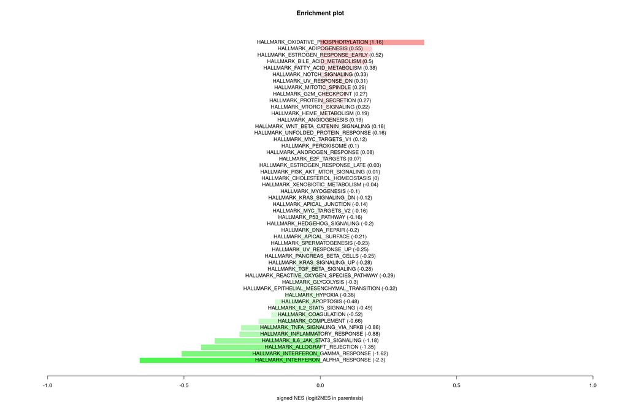

```r
plot(ans)
```

A meaningful display follows.

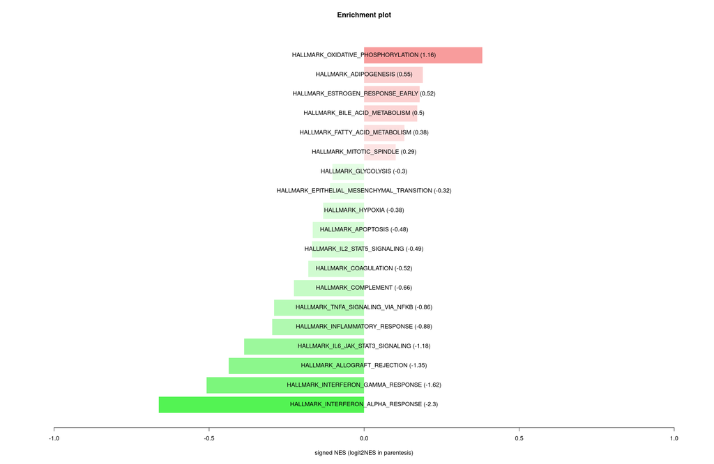

```r
plot(cut_by_significance(ans), top = 30)
```

Here, the maximum number of bars has been restricted to 30.

The horizontal axis (signed-NES) is a linear transformation of the NES:
$$signed\mbox-NES = 2\cdot NES -
1$$
necessary to a) signal the direction of the association, and b) to bound the bars between -1.0 and 1.0

The network plot needs to specify ‘as.network = TRUE’ and provide the gene-sets collection.

```r
plot(cut_by_significance(ans), gene_sets = geneSets, as.network = TRUE)
```

[interactive chart not shown]

The similarity $S(A, B)$ between two gene-sets $A$ and $B$ comes from the convex combination
$$S(A,B)= \epsilon \cdot \delta_1(A, B)+
(1-\epsilon)\cdot \delta_0(A, B),$$
with $0\leq \epsilon \leq 1$, and $\delta_0$ is the Jaccard similarity, while $\delta_1$ is the overlap index. $logit2NES$ controls the color of the balls: red for those with positive values (associated with the treatment), green otherwise. $actualSize$ controls the dimension of the balls.

# Over-representation (Fisher’s exact) test

Since version 1.2, a new function has been add to implement the overepresentation test (Fisher’s exact text) that is integrated with both the tabular and graphical function of this package.

Getting the gene sets and the gene-profile

```r
#geneSets <- get_geneSets_from_msigdbr(category = "C5", subcategory = "CC", what = "gene_symbol")

#fname <- system.file("extdata", package="massiveGST")
#fname <- file.path(fname, "pre_ranked_list.txt")
#geneProfile <- get_geneProfile(fname)
```

To mimic a set of significant genes coming from a differential expression procedure, we get the first 500 genes in the pre-ranked list,

```r
geneList <- names(head(geneProfile, 500))
```

and run the enrichment analysis

```r
ans <- massiveORT(geneList, geneSets)
```

```
## greater
```

The function massiveORT essentially is a wrapper to the function fisher.test in charge to 1) arrange the input to feed fisher.test in sequence for each gene set, 2) arrange the output in a data frame compatible with the other function of the package, and 3) compute the universe of genes for the analysis.

By default, the universe of genes necessary to the Fisher’s test is computed as the collection of genes included at lest once in any gene-set. The function allows to consider a different universe. Se help file.

The tabular result comes from

```r
summary(cut_by_significance(ans), as.formattable = TRUE)
```

|  | collection | universe size | geneList size | geneSet size | geneList in geneSet | odds_ratio | log2 odds_ratio | p.value | BH.value | B.value | relevance |
| --- | --- | --- | --- | --- | --- | --- | --- | --- | --- | --- | --- |
| HALLMARK_OXIDATIVE_PHOSPHORYLATION | /tmp/RtmptH2F6x/Rinstde3cb6705351a/massiveGST/extdata/h.all.v2024.1.Hs.symbols.gmt | 4384 | 154 | 200 | 28 | 5.2390 | 2.3893 | 1.3e-10 | 6.5e-09 | 6.5e-09 | 44 |
| HALLMARK_BILE_ACID_METABOLISM | /tmp/RtmptH2F6x/Rinstde3cb6705351a/massiveGST/extdata/h.all.v2024.1.Hs.symbols.gmt | 4384 | 154 | 112 | 12 | 3.4884 | 1.8026 | 4.9e-04 | 1.2e-02 | 2.4e-02 | 34 |

The graphical output is from

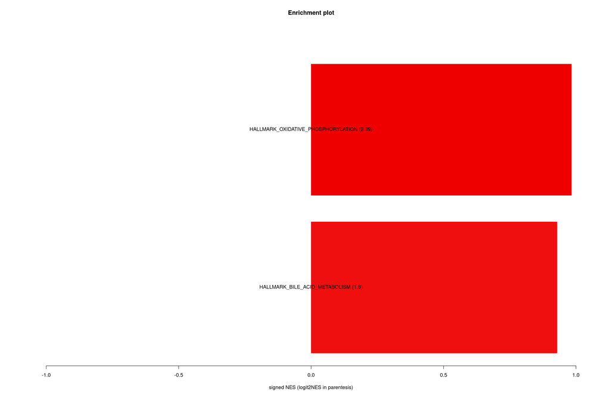

```r
plot(cut_by_significance(ans))
```

and

```r
plot(ans, gene_sets = geneSets, as.network = TRUE)
```

[interactive chart not shown]